# ECON 413 Introduction to Data Science

Erol Taymaz  
Department of Economics  
Middle East Technical University

22 February 2017

# Topics

- What is “Data Science”?
- Why is data science important?
- The data science process
- What is R?

# What is “Data Science”?

Data science, also known as data-driven science, is an interdisciplinary field about scientific methods, processes and systems to **extract knowledge** or insights from **data in various forms**, either structured or unstructured …

Data science is a “concept to unify statistics, data analysis and their related methods” in order to “understand and analyze actual phenomena” with data. It employs techniques and theories drawn from many fields within the broad areas of mathematics, statistics, information science, and computer science, in particular from the subdomains of machine learning, classification, cluster analysis, data mining, databases, and visualization. ([Wikipedia/Data Science](https://en.wikipedia.org/wiki/Data_science))

# What is “data”?

Everything that can be stored in a computer memory!

- Penn World Tables
- 5-Year Development Plan
- www.sahibinden.com

# What is “data”?

- A map
- A picture

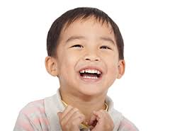

- A video
- Anything that can be stored in a computer memory

# Why is data science important?

- An explosion of data and data sources
- Everybody and everything generates data everytime
  - Walking around by mobile phone
  - Using your credit card
  - Browsing the Internet
  - Buying a certain product
- Easy access to the data (open data sources, Wikipedia!)
- Ability to extract value from the data - not just our own data, but all of the available data
- Ability to use the tools necessary to collect, analyze and present the data

# Trump’s tweets

- Donald Trump’s tweet sent from two phones, an iPhone and an Android device
- Data Scientist David Robinson revealed that those sent from an Android device were likely sent by the candidate himself, while those sent from an iPhone were likely sent by campaign staffers
- How did he find it?
  - Used R
  - Conducted a sentiment analysis
  - Found a difference?
  - See [David Robinson, “Text analysis of Trump’s tweets confirms he writes only the (angrier) Android half”](http://varianceexplained.org/r/trump-tweets/)

# Why is data science important?

The 50 Best Jobs in America in 2017

# Why is data science important?

The 50 Best Jobs in America in 2017

- Data Scientist
- DevOps Engineer
- Data Engineer
- Tax Manager
- Analytics Manager

Source: [Glassdoor/50 Best Jobs in America](https://www.glassdoor.com/List/Best-Jobs-in-America-LST_KQ0,20.htm)

# Data Science Process

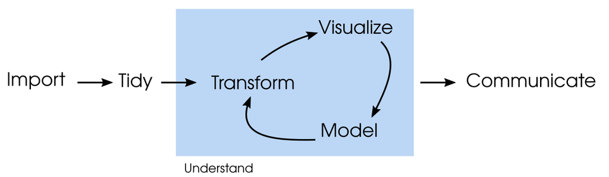

# What is ECON 413

- An *introduction* to data science
  - An introduction to the main tools and ideas in the data scientist’s toolbox.
  - How to collect, retrieve, scrap, check, clean, analyze, understand, visualize, and present the data
- An *introduction* to R programming

# Textbooks

**Textbooks**

- Everitt, Brian S. and Hothorn, Torsten (2009), *A Handbook of Statistical Analyses Using R*, Chapman and Hall/CRC.
- Peng, Roger D. (2015), *R Programming for Data Science*, Leanpub.
- Venables, W. N., Smith, D. M. and the R Core Team (2015), *An Introduction to R*, R Core Team.
- Wickham, Hadley (2014), *Advanced R*, Chapman & Hall/CRC.
- Wickham, Hadley (2016), *ggplot2: Elegant Graphics for Data Analysis*, Springer.
- Zumel, N. and Mount, J. (2014), *Practical Data Science with R*, Manning Publications.

# Topics

1. Introduction to Data Science
- What is data science?
- Why is data science important?
- The data science process
2. Introduction to R
- What is R?
- R language basics
- RStudio basics
3. Data visualization
- Data structures
- File types
- ggplot basics
- Animation
- Data exploration
- Data presentation
4. Data structures
- Data structures in R
- Matrix
- Data frame
- Data table
5. Functions
- Function components
- Function arguments
- Special functions
6. Loops and loop functions
- Looping in R
- Loop functions
7. Transforming and cleaning data
- Data cleaning
- Data merging
- Missing observations
8. Reading and collecting data
- Reading data files
- Web sources
9. Descriptive statistics
- Univariate descriptive statistics
- Bivariate descriptive statistics
10. Statistical modeling
- Statistical models
- Linear regression models
- Panel data models
11. Text mining
- Reading text data
- Analyzing text data
12. Maps
- Map functions in R
- Map visualizations
13. Networks
- Network analysis basics
- Network visualizations
- International trade networks
14. Reproducible research
- Rmarkdown basics
- Presentation basics

# Grading

- The course consists of lectures, practices (assignments) and a project.
- Practices involve performing a specific task about collecting, cleaning, analyzing, visualizing and presenting the data about a certain topic relevant for economists. Practices will be submitted individually.
- The project will involve all components of data analysis process, and students are encouraged to work in teams of two or three for a project. The project will seek to answer an important real-world probem. The students will collect and clean th data, model the problem, visualize the data and their analysis, and present their findings by using R.
- Course grades will be based on 5 practices (10 % each), and a (group) project (50 %).

# What is R?

- A programming language (interpreter)
- A statistics package
- **An environment for statistical computing and graphics**
- Developed by a community
  - Extended with ‘packages’ that contain data, code, and documentation

# What is R?

- R is a flavor of the S computer language
- S was developed by John Chambers at Bell Labs in the late 1970s
  - *[W]e wanted users to be able to begin in an interactive environment, where they did not consciously think of themselves as programming. Then as their needs became clearer and their sophistication increased, they should be able to slide gradually into programming, when the language and system aspects would become more important.* (John Chambers)
- 1991 R is created by Ross Ihaka and Robert Gentleman
  - Why **R**?
- 1993 R is made public
- 1995 R becomes Open Source (GNU General Public License)
- 1997 R Core Group is formed
- 2000 Version 1.0.0 ships

# Why R?

Why not Stata, or SPSS, or …?

- A flexible programming language
- Open Source and free (philosophy, or practical reasons)
  - It is free to study the code
  - It is free to redistribute it
  - It is free to modify it
  - It is free to redistribute the modified version
    - It is free of charge, too
- Platform independent (Linux, Mac, Windows, desktops, servers)
- Easy to share with others
- Suitable for almost all scientific disciplines
  - Extensive, diverse and growing community
  - Ever increasing number of packages
- Easy interactions with other programs (web, presentation, databases, big data, etc.)
- **Part of the open source toolchain of research (from data analysis to reporting, for the web or a thesis)**

# Why R?

- **Advantages**
  - Free of charge, easy to install
  - Strong community support
  - Up-to-date
  - Can complement / can be complemented by other programs
  - Requires user knowledge - user thinks about what s/he is doing
- **Drawbacks**
  - Steep learning curve
  - Not user friendly
  - All objects are stored in the computer memory
  - Slower than compiled languages
  - Easy to make mistakes, difficult to find the sources of mistakes

# Why R?

- The number of scholarly articles found by Google Scholar

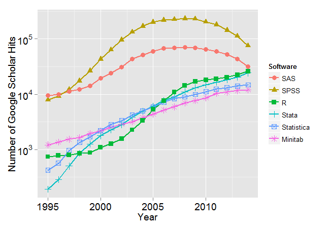

- Number of people who follow each software on LinkedIn and Quara

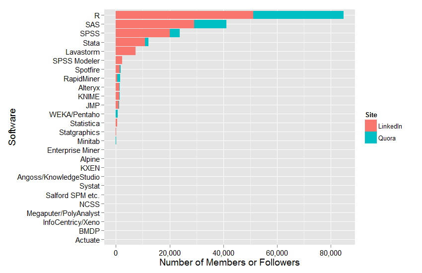

- Number of R packages available on its main distribution site

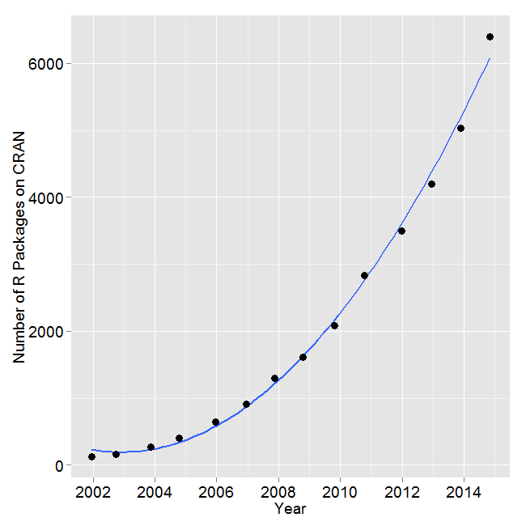

# Data science process with R

Assume that we need to forecast $/TL exchange rate and report results every week

- Download the data from CRBT web site
- Prepare the data file
- Analyze the data
  - Use ARIMA model
- Prepare the chart
- Make a presentation file

# Data science process with R

```r
library(ggplot2)
library(forecast)

exd <- read.csv("https://raw.githubusercontent.com/etaymaz/econ413/master/Data/TR_exr.csv",
                  header = F, sep = ";", skip = 11,
                  col.names = c("date", "euro", "usd"),
                  colClasses = c("character", "numeric", "numeric"))

exd <- subset(exd, (!is.na(euro)) & euro != 0)
exd$date <- as.Date(exd$date, format = "%d-%m-%Y")
usd <- window(ts(exd$usd, frequency = 52, start = c(1999, 1)), start = 2015)
musd <- auto.arima(usd)
fusd <- forecast(musd, h= 52)
```

# 1-year forecasts for US/TL

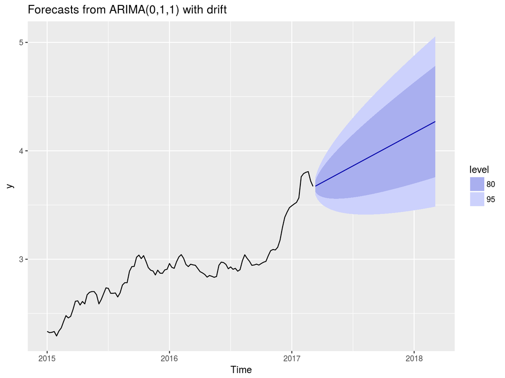

```r
autoplot(fusd)
```

# To do this week

- Install R
  - Base R and most R packages are available at cran.r-project.org
- Install RStudio
- Install packages rmarkdown, ggplot, data.table, dplyr